# "Visit with Us" Project

## Description

### Background and Context

You are a Data Scientist for a tourism company named "Visit with us". The Policy Maker of the company wants to enable and establish a viable business model to expand the customer base.

A viable business model is a central concept that helps you to understand the existing ways of doing the business and how to change the ways for the benefit of the tourism sector.

One of the ways to expand the customer base is to introduce a new offering of packages.

Currently, there are 5 types of packages the company is offering - Basic, Standard, Deluxe, Super Deluxe, King. Looking at the data of the last year, we observed that 18% of the customers purchased the packages.

The company in the last campaign contacted the customers at random without looking at the available information. However, this time company is now planning to launch a new product i.e. Wellness Tourism Package. Wellness Tourism is defined as Travel that allows the traveler to maintain, enhance or kick-start a healthy lifestyle, and support or increase one's sense of well-being, and wants to harness the available data of existing and potential customers to make the marketing expenditure more efficient.

You as a Data Scientist at "Visit with us" travel company has to analyze the customers' data and information to provide recommendations to the Policy Maker and Marketing Team and also build a model to predict the potential customer who is going to purchase the newly introduced travel package.

### Objective

To predict which customer is more likely to purchase the newly introduced travel package.

##### Data Dictionary

Customer details:

- CustomerID: Unique customer ID
- ProdTaken**: Whether the customer has purchased a package or not (0: No, 1: Yes)
- Age: Age of customer
- TypeofContact: How customer was contacted (Company Invited or Self Inquiry)
- CityTier: City tier depends on the development of a city, population, facilities, and living standards. The categories are ordered i.e. Tier 1 > Tier 2 > Tier 3
- Occupation: Occupation of customer
- Gender: Gender of customer
- NumberOfPersonVisiting: Total number of persons planning to take the trip with the customer
- PreferredPropertyStar: Preferred hotel property rating by customer
- MaritalStatus: Marital status of customer
- NumberOfTrips: Average number of trips in a year by customer
- Passport: The customer has a passport or not (0: No, 1: Yes)
- OwnCar: Whether the customers own a car or not (0: No, 1: Yes)
- NumberOfChildrenVisiting: Total number of children with age less than 5 planning to take the trip with the customer
- Designation: Designation of the customer in the current organization
- MonthlyIncome: Gross monthly income of the customer

Customer interaction data:

- PitchSatisfactionScore: Sales pitch satisfaction score
- ProductPitched: Product pitched by the salesperson
- NumberOfFollowups: Total number of follow-ups has been done by the salesperson after the sales pitch
- DurationOfPitch: Duration of the pitch by a salesperson to the customer

** ProdTaken is our target/dependent variable

### Loading Libraries

```python
# Library to suppress warnings or deprecation notes
import warnings
warnings.filterwarnings('ignore')

# Libraries to help with reading and manipulating data
import numpy as np
import pandas as pd

# Libraries to help with data visualization
import matplotlib.pyplot as plt
%matplotlib inline
import seaborn as sns

# Libraries to split data, impute missing values
from sklearn.model_selection import train_test_split
from sklearn.impute import SimpleImputer

# Libraries to import decision tree classifier and different ensemble classifiers
from sklearn.ensemble import BaggingClassifier
from sklearn.ensemble import RandomForestClassifier
from sklearn.ensemble import AdaBoostClassifier, GradientBoostingClassifier
from xgboost import XGBClassifier
from sklearn.ensemble import StackingClassifier
from sklearn.tree import DecisionTreeClassifier

# Libtune to tune model, get different metric scores
from sklearn import metrics
from sklearn.metrics import confusion_matrix, classification_report, accuracy_score, precision_score, recall_score, f1_score, roc_auc_score
from sklearn.model_selection import GridSearchCV
```

### Loading the data

```python
data_dictionary = pd.read_excel("Tourism.xlsx", sheet_name='Data Dict', header=1, usecols = "C:D")
```

```python
data_dictionary
```

|  | Variable | Discerption |
| --- | --- | --- |
| 0 | CustomerID | Unique customer ID |
| 1 | ProdTaken | Whether the customer has purchased a package o... |
| 2 | Age | Age of customer |
| 3 | TypeofContact | How customer was contacted (Company Invited or... |
| 4 | CityTier | City tier depends on the development of a city... |
| 5 | DurationOfPitch | Duration of the pitch by a salesperson to the ... |
| 6 | Occupation | Occupation of customer |
| 7 | Gender | Gender of customer |
| 8 | NumberOfPersonVisiting | Total number of persons planning to take the t... |
| 9 | NumberOfFollowups | Total number of follow-ups has been done by sa... |
| 10 | ProductPitched | Product pitched by the salesperson |
| 11 | PreferredPropertyStar | Preferred hotel property rating by customer |
| 12 | MaritalStatus | Marital status of customer |
| 13 | NumberOfTrips | Average number of trips in a year by customer |
| 14 | Passport | The customer has a passport or not (0: No, 1: ... |
| 15 | PitchSatisfactionScore | Sales pitch satisfaction score |
| 16 | OwnCar | Whether the customers own a car or not (0: No,... |
| 17 | NumberOfChildrenVisiting | Total number of children with age less than 5 ... |
| 18 | Designation | Designation of the customer in the current org... |
| 19 | MonthlyIncome | Gross monthly income of the customer |

```python
# loading the dataset
tourism_data = pd.read_excel("Tourism.xlsx", 'Tourism')
```

```python
tourism_data.head()
```

|  | CustomerID | ProdTaken | Age | TypeofContact | CityTier | DurationOfPitch | Occupation | Gender | NumberOfPersonVisiting | NumberOfFollowups | ProductPitched | PreferredPropertyStar | MaritalStatus | NumberOfTrips | Passport | PitchSatisfactionScore | OwnCar | NumberOfChildrenVisiting | Designation | MonthlyIncome |
| --- | --- | --- | --- | --- | --- | --- | --- | --- | --- | --- | --- | --- | --- | --- | --- | --- | --- | --- | --- | --- |
| 0 | 200000 | 1 | 41.0 | Self Enquiry | 3 | 6.0 | Salaried | Female | 3 | 3.0 | Deluxe | 3.0 | Single | 1.0 | 1 | 2 | 1 | 0.0 | Manager | 20993.0 |
| 1 | 200001 | 0 | 49.0 | Company Invited | 1 | 14.0 | Salaried | Male | 3 | 4.0 | Deluxe | 4.0 | Divorced | 2.0 | 0 | 3 | 1 | 2.0 | Manager | 20130.0 |
| 2 | 200002 | 1 | 37.0 | Self Enquiry | 1 | 8.0 | Free Lancer | Male | 3 | 4.0 | Basic | 3.0 | Single | 7.0 | 1 | 3 | 0 | 0.0 | Executive | 17090.0 |
| 3 | 200003 | 0 | 33.0 | Company Invited | 1 | 9.0 | Salaried | Female | 2 | 3.0 | Basic | 3.0 | Divorced | 2.0 | 1 | 5 | 1 | 1.0 | Executive | 17909.0 |
| 4 | 200004 | 0 | NaN | Self Enquiry | 1 | 8.0 | Small Business | Male | 2 | 3.0 | Basic | 4.0 | Divorced | 1.0 | 0 | 5 | 1 | 0.0 | Executive | 18468.0 |

```python
tourism_data.shape
```

```
(4888, 20)
```

```python
df = tourism_data.copy()
```

```python
df.head()
```

|  | CustomerID | ProdTaken | Age | TypeofContact | CityTier | DurationOfPitch | Occupation | Gender | NumberOfPersonVisiting | NumberOfFollowups | ProductPitched | PreferredPropertyStar | MaritalStatus | NumberOfTrips | Passport | PitchSatisfactionScore | OwnCar | NumberOfChildrenVisiting | Designation | MonthlyIncome |
| --- | --- | --- | --- | --- | --- | --- | --- | --- | --- | --- | --- | --- | --- | --- | --- | --- | --- | --- | --- | --- |
| 0 | 200000 | 1 | 41.0 | Self Enquiry | 3 | 6.0 | Salaried | Female | 3 | 3.0 | Deluxe | 3.0 | Single | 1.0 | 1 | 2 | 1 | 0.0 | Manager | 20993.0 |
| 1 | 200001 | 0 | 49.0 | Company Invited | 1 | 14.0 | Salaried | Male | 3 | 4.0 | Deluxe | 4.0 | Divorced | 2.0 | 0 | 3 | 1 | 2.0 | Manager | 20130.0 |
| 2 | 200002 | 1 | 37.0 | Self Enquiry | 1 | 8.0 | Free Lancer | Male | 3 | 4.0 | Basic | 3.0 | Single | 7.0 | 1 | 3 | 0 | 0.0 | Executive | 17090.0 |
| 3 | 200003 | 0 | 33.0 | Company Invited | 1 | 9.0 | Salaried | Female | 2 | 3.0 | Basic | 3.0 | Divorced | 2.0 | 1 | 5 | 1 | 1.0 | Executive | 17909.0 |
| 4 | 200004 | 0 | NaN | Self Enquiry | 1 | 8.0 | Small Business | Male | 2 | 3.0 | Basic | 4.0 | Divorced | 1.0 | 0 | 5 | 1 | 0.0 | Executive | 18468.0 |

```python
df.tail()
```

|  | CustomerID | ProdTaken | Age | TypeofContact | CityTier | DurationOfPitch | Occupation | Gender | NumberOfPersonVisiting | NumberOfFollowups | ProductPitched | PreferredPropertyStar | MaritalStatus | NumberOfTrips | Passport | PitchSatisfactionScore | OwnCar | NumberOfChildrenVisiting | Designation | MonthlyIncome |
| --- | --- | --- | --- | --- | --- | --- | --- | --- | --- | --- | --- | --- | --- | --- | --- | --- | --- | --- | --- | --- |
| 4883 | 204883 | 1 | 49.0 | Self Enquiry | 3 | 9.0 | Small Business | Male | 3 | 5.0 | Deluxe | 4.0 | Unmarried | 2.0 | 1 | 1 | 1 | 1.0 | Manager | 26576.0 |
| 4884 | 204884 | 1 | 28.0 | Company Invited | 1 | 31.0 | Salaried | Male | 4 | 5.0 | Basic | 3.0 | Single | 3.0 | 1 | 3 | 1 | 2.0 | Executive | 21212.0 |
| 4885 | 204885 | 1 | 52.0 | Self Enquiry | 3 | 17.0 | Salaried | Female | 4 | 4.0 | Standard | 4.0 | Married | 7.0 | 0 | 1 | 1 | 3.0 | Senior Manager | 31820.0 |
| 4886 | 204886 | 1 | 19.0 | Self Enquiry | 3 | 16.0 | Small Business | Male | 3 | 4.0 | Basic | 3.0 | Single | 3.0 | 0 | 5 | 0 | 2.0 | Executive | 20289.0 |
| 4887 | 204887 | 1 | 36.0 | Self Enquiry | 1 | 14.0 | Salaried | Male | 4 | 4.0 | Basic | 4.0 | Unmarried | 3.0 | 1 | 3 | 1 | 2.0 | Executive | 24041.0 |

```python
df.shape
```

```
(4888, 20)
```

```python
df.info()
```

```
<class 'pandas.core.frame.DataFrame'>
RangeIndex: 4888 entries, 0 to 4887
Data columns (total 20 columns):
 #   Column                    Non-Null Count  Dtype
---  ------                    --------------  -----
 0   CustomerID                4888 non-null   int64
 1   ProdTaken                 4888 non-null   int64
 2   Age                       4662 non-null   float64
 3   TypeofContact             4863 non-null   object
 4   CityTier                  4888 non-null   int64
 5   DurationOfPitch           4637 non-null   float64
 6   Occupation                4888 non-null   object
 7   Gender                    4888 non-null   object
 8   NumberOfPersonVisiting    4888 non-null   int64
 9   NumberOfFollowups         4843 non-null   float64
 10  ProductPitched            4888 non-null   object
 11  PreferredPropertyStar     4862 non-null   float64
 12  MaritalStatus             4888 non-null   object
 13  NumberOfTrips             4748 non-null   float64
 14  Passport                  4888 non-null   int64
 15  PitchSatisfactionScore    4888 non-null   int64
 16  OwnCar                    4888 non-null   int64
 17  NumberOfChildrenVisiting  4822 non-null   float64
 18  Designation               4888 non-null   object
 19  MonthlyIncome             4655 non-null   float64
dtypes: float64(7), int64(7), object(6)
memory usage: 763.9+ KB
```

#### Observation

- Many columns are of type object i.e. strings. These need to be converted to ordinal type
- Other variables, such as Age and NumberofChildrenVisiting, which we would expect to be integers are classified as float data type

```python
df.nunique()
```

```
CustomerID                  4888
ProdTaken                      2
Age                           44
TypeofContact                  2
CityTier                       3
DurationOfPitch               34
Occupation                     4
Gender                         3
NumberOfPersonVisiting         5
NumberOfFollowups              6
ProductPitched                 5
PreferredPropertyStar          3
MaritalStatus                  4
NumberOfTrips                 12
Passport                       2
PitchSatisfactionScore         5
OwnCar                         2
NumberOfChildrenVisiting       4
Designation                    5
MonthlyIncome               2475
dtype: int64
```

#### Observation

- We can drop 'CustomerID' column as it is an ID variable and will not add value to the model.

```python
#Dropping two columns from the dataframe
df.drop(columns=['CustomerID'], inplace=True)
```

```python
df.describe(include='all').T
```

|  | count | unique | top | freq | mean | std | min | 25% | 50% | 75% | max |
| --- | --- | --- | --- | --- | --- | --- | --- | --- | --- | --- | --- |
| ProdTaken | 4888.0 | NaN | NaN | NaN | 0.188216 | 0.390925 | 0.0 | 0.0 | 0.0 | 0.0 | 1.0 |
| Age | 4662.0 | NaN | NaN | NaN | 37.622265 | 9.316387 | 18.0 | 31.0 | 36.0 | 44.0 | 61.0 |
| TypeofContact | 4863 | 2 | Self Enquiry | 3444 | NaN | NaN | NaN | NaN | NaN | NaN | NaN |
| CityTier | 4888.0 | NaN | NaN | NaN | 1.654255 | 0.916583 | 1.0 | 1.0 | 1.0 | 3.0 | 3.0 |
| DurationOfPitch | 4637.0 | NaN | NaN | NaN | 15.490835 | 8.519643 | 5.0 | 9.0 | 13.0 | 20.0 | 127.0 |
| Occupation | 4888 | 4 | Salaried | 2368 | NaN | NaN | NaN | NaN | NaN | NaN | NaN |
| Gender | 4888 | 3 | Male | 2916 | NaN | NaN | NaN | NaN | NaN | NaN | NaN |
| NumberOfPersonVisiting | 4888.0 | NaN | NaN | NaN | 2.905074 | 0.724891 | 1.0 | 2.0 | 3.0 | 3.0 | 5.0 |
| NumberOfFollowups | 4843.0 | NaN | NaN | NaN | 3.708445 | 1.002509 | 1.0 | 3.0 | 4.0 | 4.0 | 6.0 |
| ProductPitched | 4888 | 5 | Basic | 1842 | NaN | NaN | NaN | NaN | NaN | NaN | NaN |
| PreferredPropertyStar | 4862.0 | NaN | NaN | NaN | 3.581037 | 0.798009 | 3.0 | 3.0 | 3.0 | 4.0 | 5.0 |
| MaritalStatus | 4888 | 4 | Married | 2340 | NaN | NaN | NaN | NaN | NaN | NaN | NaN |
| NumberOfTrips | 4748.0 | NaN | NaN | NaN | 3.236521 | 1.849019 | 1.0 | 2.0 | 3.0 | 4.0 | 22.0 |
| Passport | 4888.0 | NaN | NaN | NaN | 0.290917 | 0.454232 | 0.0 | 0.0 | 0.0 | 1.0 | 1.0 |
| PitchSatisfactionScore | 4888.0 | NaN | NaN | NaN | 3.078151 | 1.365792 | 1.0 | 2.0 | 3.0 | 4.0 | 5.0 |
| OwnCar | 4888.0 | NaN | NaN | NaN | 0.620295 | 0.485363 | 0.0 | 0.0 | 1.0 | 1.0 | 1.0 |
| NumberOfChildrenVisiting | 4822.0 | NaN | NaN | NaN | 1.187267 | 0.857861 | 0.0 | 1.0 | 1.0 | 2.0 | 3.0 |
| Designation | 4888 | 5 | Executive | 1842 | NaN | NaN | NaN | NaN | NaN | NaN | NaN |
| MonthlyIncome | 4655.0 | NaN | NaN | NaN | 23619.853491 | 5380.698361 | 1000.0 | 20346.0 | 22347.0 | 25571.0 | 98678.0 |

### Looking more closely at Gender feature

```python
df["Gender"].value_counts()
```

```
Male       2916
Female     1817
Fe Male     155
Name: Gender, dtype: int64
```

#### Observation

- It looks like 155 values have been mislabeled as "Fe Male". Correction needed here

#### Gender feature: data clean-up

```python
# Extracting space from "Fe Male" values
def remove_whitespace(x):
    """
    Helper function to remove any blank space from a string
    x: a string
    """
    try:
        # Remove spaces inside of the string
        x = "".join(x.split())

    except:
        pass
    return x

df.Gender = df.Gender.apply(remove_whitespace)
```

```python
# Formatting all values in column as title to handle upper case "M" in FeMale
df.Gender = df.Gender.str.title()
```

```python
df.Gender.value_counts()
```

```
Male      2916
Female    1972
Name: Gender, dtype: int64
```

#### Observation

- Data clean up completed successfully

## Handling missing values

#### Getting percentage of missing values per column

```python
((df.isnull().sum().sort_values(ascending=False))/len(df))*100
```

```
DurationOfPitch             5.135025
MonthlyIncome               4.766776
Age                         4.623568
NumberOfTrips               2.864157
NumberOfChildrenVisiting    1.350245
NumberOfFollowups           0.920622
PreferredPropertyStar       0.531915
TypeofContact               0.511457
Designation                 0.000000
OwnCar                      0.000000
PitchSatisfactionScore      0.000000
Passport                    0.000000
ProdTaken                   0.000000
MaritalStatus               0.000000
NumberOfPersonVisiting      0.000000
Gender                      0.000000
Occupation                  0.000000
CityTier                    0.000000
ProductPitched              0.000000
dtype: float64
```

#### Observation

- Null values observed in several columns - these will need to be addressed
- Except for missing values in DurationOfPitch which are slightly over 5%, missing values do not surpass 5% of the total number of values in each column
- Most of the missing values are observed in numeric features - we will look at the value distributions for each column carefully to determine the best course of action for missing value imputation

#### Columns with mising values:

- DurationOfPitch
- MonthlyIncome
- Age
- NumberOfTrips
- NumberOfChildrenVisiting
- NumberOfFollowups
- PreferredPropertyStar
- TypeofContact

#### Let's examine value distributions more closely of the missing value features listed above through histograms and barplots

```python
# Function below helps to create a boxplot and histogram for any input numerical
# variable. It takes the numerical column as the input and returns the boxplots
# and histograms for the variable.

def histogram_boxplot(feature, figsize=(15,10), bins = None):
    """ Boxplot and histogram combined
    feature: 1-d feature array
    figsize: size of fig (default (9,8))
    bins: number of bins (default None / auto)
    """
    f2, (ax_box2, ax_hist2) = plt.subplots(nrows = 2, # Number of rows of the subplot grid= 2
                                           sharex = True, # x-axis will be shared among all subplots
                                           gridspec_kw = {"height_ratios": (.25, .75)},
                                           figsize = figsize
                                           ) # creating the 2 subplots
    sns.boxplot(feature, ax=ax_box2, showmeans=True, color='green') # boxplot will be created and a star will indicate the mean value of the column
    sns.distplot(feature, kde=F, ax=ax_hist2, bins=bins) if bins else sns.distplot(feature, kde=False, ax=ax_hist2) # For histogram
    ax_hist2.axvline(np.mean(feature), color='g', linestyle='--') # Add mean to the histogram
    ax_hist2.axvline(np.median(feature), color='black', linestyle='-') # Add median to the histogram
```

#### Treating missing values in continuous numeric features

##### DurationOfPitch

```python
df["DurationOfPitch"].describe()
```

```
count    4637.000000
mean       15.490835
std         8.519643
min         5.000000
25%         9.000000
50%        13.000000
75%        20.000000
max       127.000000
Name: DurationOfPitch, dtype: float64
```

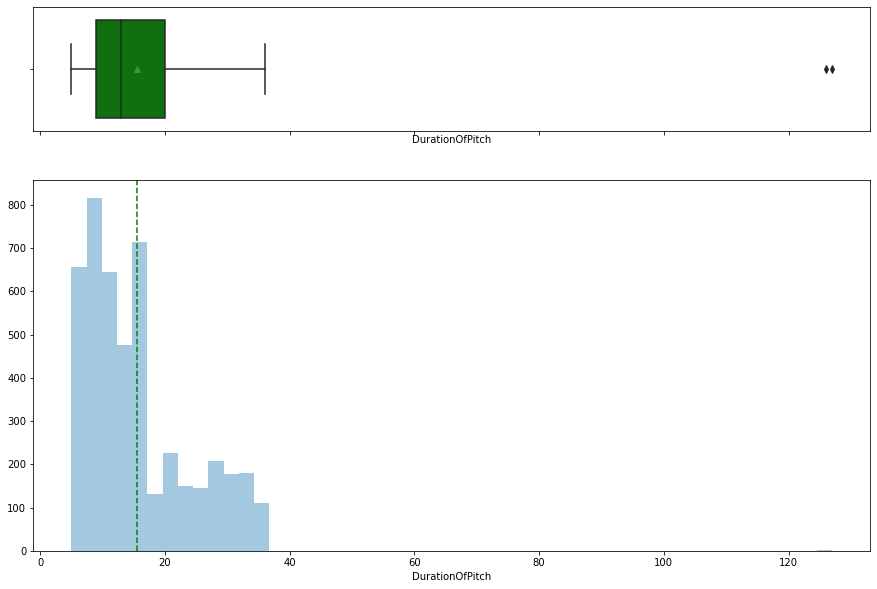

```python
histogram_boxplot(df['DurationOfPitch'])
```

#### Observation

- We observe here a positive/right-skewed distribution with mean greater than median value. This indicates missing values should be filled with median rather than mean

##### MonthlyIncome

```python
df["MonthlyIncome"].describe()
```

```
count     4655.000000
mean     23619.853491
std       5380.698361
min       1000.000000
25%      20346.000000
50%      22347.000000
75%      25571.000000
max      98678.000000
Name: MonthlyIncome, dtype: float64
```

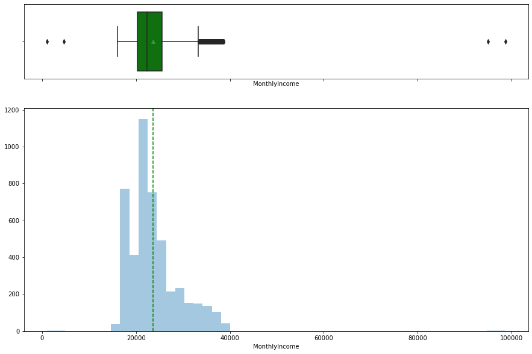

```python
histogram_boxplot(df['MonthlyIncome'])
```

#### Observation

- We observe here a positive/right-skewed distribution with mean greater than median value which indicates missing values should be filled with median rather than mean

##### Age

```python
df["Age"].describe()
```

```
count    4662.000000
mean       37.622265
std         9.316387
min        18.000000
25%        31.000000
50%        36.000000
75%        44.000000
max        61.000000
Name: Age, dtype: float64
```

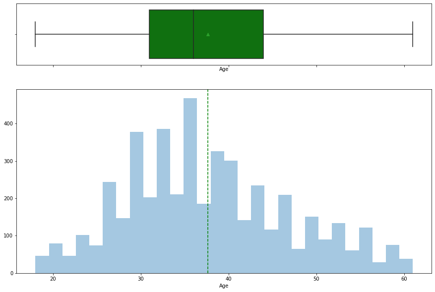

```python
histogram_boxplot(df['Age'])
```

#### Observation

- We observe a slight positive/right-skewed distribution with mean greater than median value which indicates missing values should be filled with median rather than mean

```python
#using `fillna` with continuous numeric columns DurationOfPitch, MonthlyIncome, Age
median_fillna = ['DurationOfPitch','MonthlyIncome', 'Age']
for colname in median_fillna:
    print(df[colname].isnull().sum())
    df[colname].fillna(df[colname].median(), inplace=True)
    print(df[colname].isnull().sum())
```

```
251
0
233
0
226
0
```

#### Observation

- Filling missing values for DurationOfPitch, MonthlyIncome, Age successfully handled

```python
def labeled_barplot(data, feature, perc=False, n=None):
    """
    Barplot with percentage at the top

    data: dataframe
    feature: dataframe column
    perc: whether to display percentages instead of count (default is False)
    n: displays the top n category levels (default is None, i.e., display all levels)
    """

    total = len(data[feature])  # length of the column
    count = data[feature].nunique()
    if n is None:
        plt.figure(figsize=(count + 2, 6))
    else:
        plt.figure(figsize=(n + 2, 6))

    plt.xticks(rotation=90, fontsize=15)
    ax = sns.countplot(
        data=data,
        x=feature,
        palette="Paired",
        order=data[feature].value_counts().index[:n].sort_values(),
    )

    for p in ax.patches:
        if perc == True:
            label = "{:.1f}%".format(
                100 * p.get_height() / total
            )  # percentage of each class of the category
        else:
            label = p.get_height()  # count of each level of the category

        x = p.get_x() + p.get_width() / 2  # width of the plot
        y = p.get_height()  # height of the plot

        ax.annotate(
            label,
            (x, y),
            ha="center",
            va="center",
            size=12,
            xytext=(0, 5),
            textcoords="offset points",
        )  # annotate the percentage

    plt.show()  # show the plot
```

#### Treating missing values in ordinal numeric features

##### NumberOfChildrenVisiting

```python
df["NumberOfChildrenVisiting"].describe()
```

```
count    4822.000000
mean        1.187267
std         0.857861
min         0.000000
25%         1.000000
50%         1.000000
75%         2.000000
max         3.000000
Name: NumberOfChildrenVisiting, dtype: float64
```

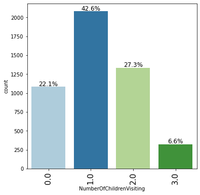

```python
labeled_barplot(df, "NumberOfChildrenVisiting", perc=True)
```

#### Observation

- Mean and median closely alligned at 1 child planned to accompany in visit

##### NumberOfFollowups

```python
df["NumberOfFollowups"].describe()
```

```
count    4843.000000
mean        3.708445
std         1.002509
min         1.000000
25%         3.000000
50%         4.000000
75%         4.000000
max         6.000000
Name: NumberOfFollowups, dtype: float64
```

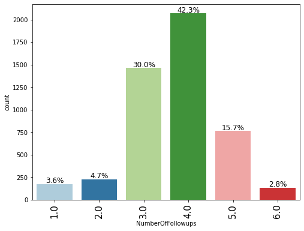

```python
labeled_barplot(df, "NumberOfFollowups", perc=True)
```

#### Observation

- Mean and median closely alligned at 4 follow ups

##### NumberOfTrips

```python
df["NumberOfTrips"].describe()
```

```
count    4748.000000
mean        3.236521
std         1.849019
min         1.000000
25%         2.000000
50%         3.000000
75%         4.000000
max        22.000000
Name: NumberOfTrips, dtype: float64
```

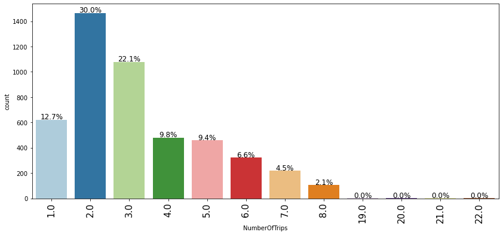

```python
labeled_barplot(df, "NumberOfTrips", perc=True)
```

#### Observation

- Mean and median closely alligned at 3 trips

##### PreferredPropertyStar

```python
df["PreferredPropertyStar"].describe()
```

```
count    4862.000000
mean        3.581037
std         0.798009
min         3.000000
25%         3.000000
50%         3.000000
75%         4.000000
max         5.000000
Name: PreferredPropertyStar, dtype: float64
```

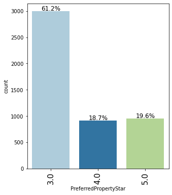

```python
labeled_barplot(df, "PreferredPropertyStar", perc=True)
```

#### Observation

- The number of stars most often preferred is 3

#### Overall observation:

- Mean will be used to fill missing values for ordinal numeric features since from the examined frequency distributions above mean and median are closely alligned

```python
#using `fillna` with ordinal numeric columns NumberOfTrips, NumberOfChildrenVisiting, NumberOfFollowups, and PreferredPropertyStar
mean_fillna = ['NumberOfTrips', 'NumberOfChildrenVisiting', 'NumberOfFollowups', 'PreferredPropertyStar']
for colname in mean_fillna:
    print(df[colname].isnull().sum())
    df[colname].fillna(df[colname].mean(), inplace=True)
    print(df[colname].isnull().sum())
```

```
140
0
66
0
45
0
26
0
```

#### Observation

- Filling missing values for NumberOfTrips, NumberOfChildrenVisiting, NumberOfFollowups, and PreferredPropertyStar successfully handled

##### TypeofContact

```python
df["TypeofContact"].describe()
```

```
count             4863
unique               2
top       Self Enquiry
freq              3444
Name: TypeofContact, dtype: object
```

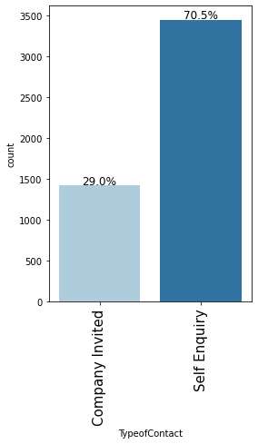

```python
labeled_barplot(df, "TypeofContact", perc=True)
```

#### Observation

- The most frequent value for TypeofContact column is "Self Enquiry" - we will use value to fill in missing values for this feature

```python
#fillna for categorical feature "TypeofContact" with most frequent category "Self Enquiry"
print(df["TypeofContact"].isnull().sum())
df["TypeofContact"].fillna("Self Enquiry", inplace = True)
print(df["TypeofContact"].isnull().sum())
```

```
25
0
```

```python
((df.isnull().sum().sort_values(ascending=False))/len(df))*100
```

```
ProdTaken                   0.0
PreferredPropertyStar       0.0
Designation                 0.0
NumberOfChildrenVisiting    0.0
OwnCar                      0.0
PitchSatisfactionScore      0.0
Passport                    0.0
NumberOfTrips               0.0
MaritalStatus               0.0
ProductPitched              0.0
Age                         0.0
NumberOfFollowups           0.0
NumberOfPersonVisiting      0.0
Gender                      0.0
Occupation                  0.0
DurationOfPitch             0.0
CityTier                    0.0
TypeofContact               0.0
MonthlyIncome               0.0
dtype: float64
```

#### Observation

- Filling missing values successfully handled

### Converting columns with an 'object' datatype into categorical variables

```python
for feature in df.columns: # Loop through all columns in the dataframe
    if df[feature].dtype == 'object': # Only apply for columns with categorical strings
        df[feature] = pd.Categorical(df[feature])# Replace strings with an integer
df.info()
```

```
<class 'pandas.core.frame.DataFrame'>
RangeIndex: 4888 entries, 0 to 4887
Data columns (total 19 columns):
 #   Column                    Non-Null Count  Dtype
---  ------                    --------------  -----
 0   ProdTaken                 4888 non-null   int64
 1   Age                       4888 non-null   float64
 2   TypeofContact             4888 non-null   category
 3   CityTier                  4888 non-null   int64
 4   DurationOfPitch           4888 non-null   float64
 5   Occupation                4888 non-null   category
 6   Gender                    4888 non-null   category
 7   NumberOfPersonVisiting    4888 non-null   int64
 8   NumberOfFollowups         4888 non-null   float64
 9   ProductPitched            4888 non-null   category
 10  PreferredPropertyStar     4888 non-null   float64
 11  MaritalStatus             4888 non-null   category
 12  NumberOfTrips             4888 non-null   float64
 13  Passport                  4888 non-null   int64
 14  PitchSatisfactionScore    4888 non-null   int64
 15  OwnCar                    4888 non-null   int64
 16  NumberOfChildrenVisiting  4888 non-null   float64
 17  Designation               4888 non-null   category
 18  MonthlyIncome             4888 non-null   float64
dtypes: category(6), float64(7), int64(6)
memory usage: 526.3 KB
```

#### Observation

- Object data types converted to category to optimize processing efficiency

### Converting non-float numeric columns to integer values

- Whole numbers expected from features below

```python
df["Age"] = df["Age"].astype(int)
df["NumberOfPersonVisiting"] = df["NumberOfPersonVisiting"].astype(int)
df["NumberOfFollowups"]=df["NumberOfFollowups"].astype(int)
df["NumberOfTrips"]=df["NumberOfTrips"].astype(int)
df["NumberOfChildrenVisiting"]=df["NumberOfChildrenVisiting"].astype(int)
df["PreferredPropertyStar"]=df["PreferredPropertyStar"].astype(int)
```

## Exploratory Data Analysis

#### Age

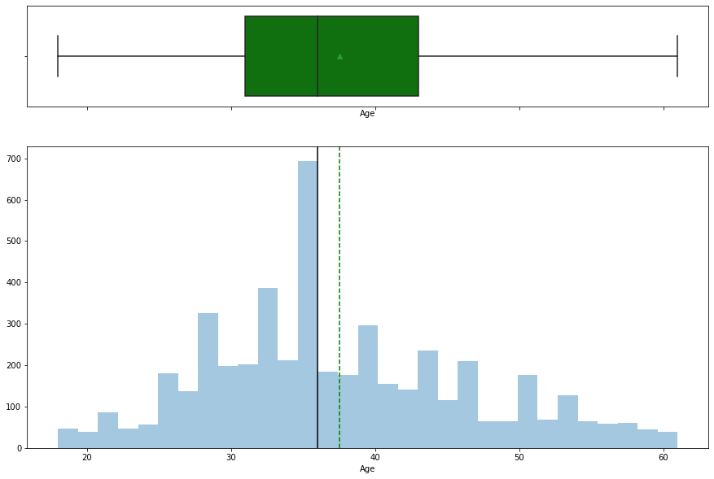

```python
histogram_boxplot(df['Age'])
```

##### Observation

- The mean and median age of Visit With Us customer hover around late 30s - mean of 37.5 and median of 36

#### DurationOfPitch

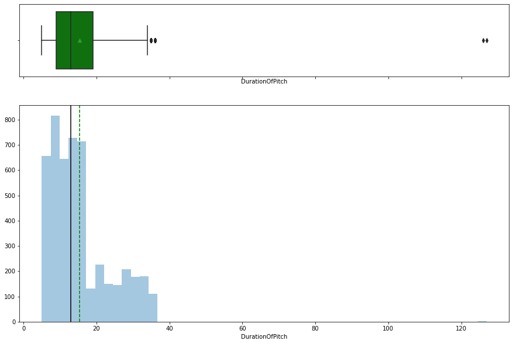

```python
histogram_boxplot(df['DurationOfPitch'])
```

##### Observation

- We observe a right-skewness in the data given the presence of large value outliers. Outliers will be handled later on

#### MonthlyIncome

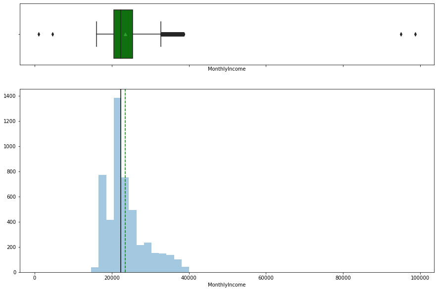

```python
histogram_boxplot(df['MonthlyIncome'])
```

#### NumberOfPersonVisiting

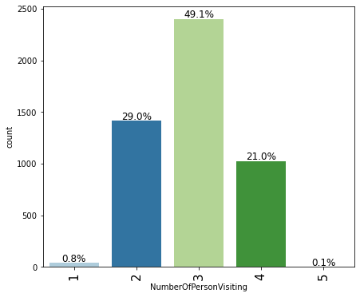

```python
labeled_barplot(df, "NumberOfPersonVisiting", perc=True)
```

##### Observation

- The most frequent value observed for number of people intended to be travelling with customer is 3 followed by 2
- Very few customers said they intended to take trip with just 1 person

#### NumberOfFollowups

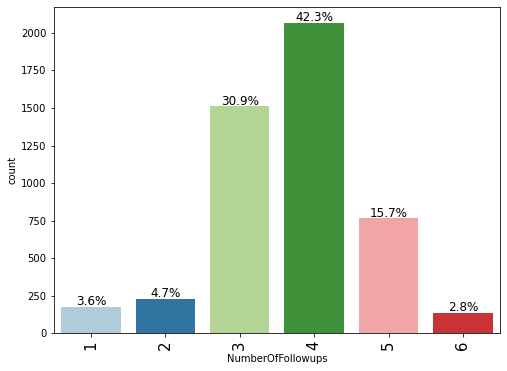

```python
labeled_barplot(df, "NumberOfFollowups", perc=True)
```

##### Observations

- Over 70% of customers received 3 to 4 follow ups from Visit With Us sales team

#### NumberOfTrips

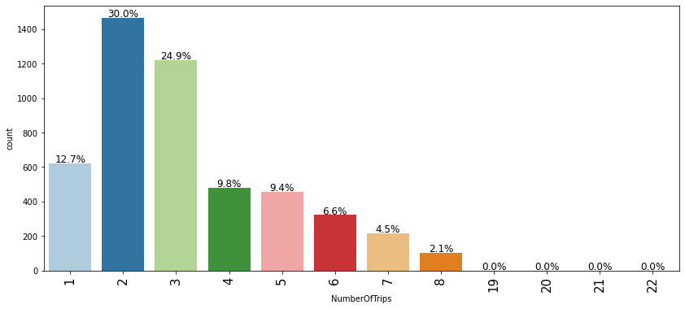

```python
labeled_barplot(df, "NumberOfTrips", perc=True)
```

##### Observation

- Over 50% of customers reported taking on average 2 to 3 trips per year

#### NumberOfChildrenVisiting

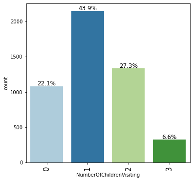

```python
labeled_barplot(df, "NumberOfChildrenVisiting", perc=True)
```

##### Observation

- 44% of customers reported planning to travel with 1 small child (age less than 5)

#### CityTier

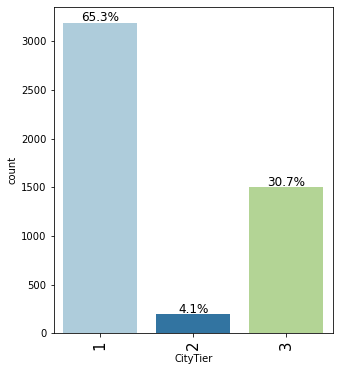

```python
labeled_barplot(df, "CityTier", perc=True)
```

##### Observation

- Metadata describes "CityTier" as depending on the development of a city, population, facilities, and living standards. The categories are ordered i.e. Tier 1 > Tier 2 > Tier 3
- The most frequent CityTier reported here as Tier 1

#### PreferredPropertyStar

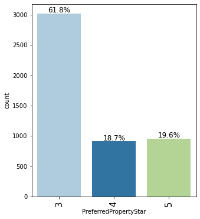

```python
labeled_barplot(df, "PreferredPropertyStar", perc=True)
```

##### Observation

- The most popular preferred hotel property rating by customers is 3 stars

#### PitchSatisfactionScore

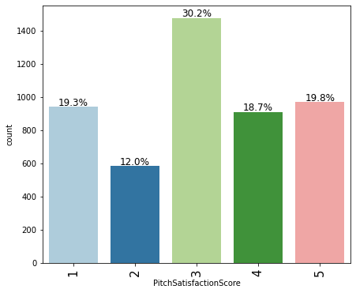

```python
labeled_barplot(df, "PitchSatisfactionScore", perc=True)
```

##### Observation

- Most common rating for sales pitch satisfaction was 3
- Near 70% of customers rated sales pitch from 3 to 5

#### Gender

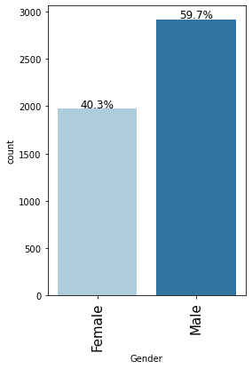

```python
labeled_barplot(df, "Gender", perc=True)
```

##### Observation

- Close to 60% of customers are male

#### MaritalStatus

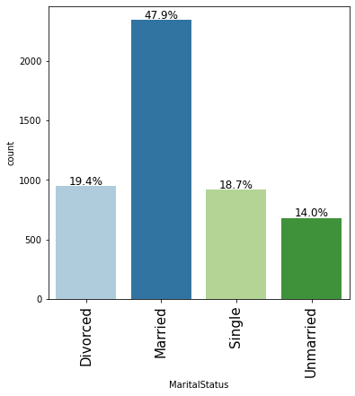

```python
labeled_barplot(df, "MaritalStatus", perc=True)
```

##### Observation

- Nearly 50% of customers are married

#### Occupation

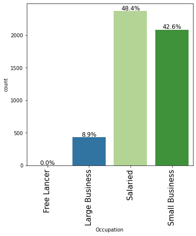

```python
labeled_barplot(df, "Occupation", perc=True)
```

##### Observation

- Most customers are salaried professionals
- 2 customers reported being free lancers

#### Designation

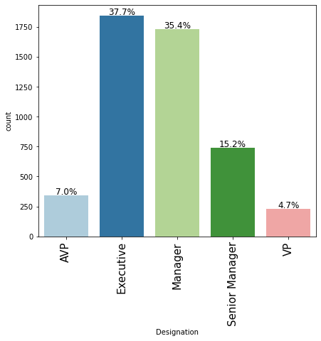

```python
labeled_barplot(df, "Designation", perc=True)
```

#### Observation

- Most customers reported being Executives (nearly 40%) followed by managers (35%)

#### Passport

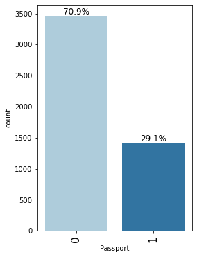

```python
labeled_barplot(df, "Passport", perc=True)
```

##### Observation

- 70% of customers report not having a passport

#### OwnCar

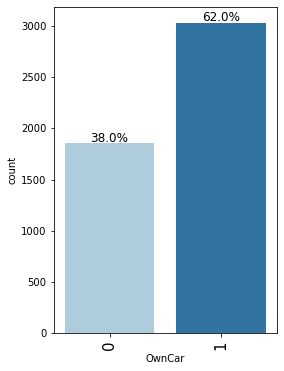

```python
labeled_barplot(df, "OwnCar", perc=True)
```

##### Observation

- 62% of customers report having a car

#### ProductPitched

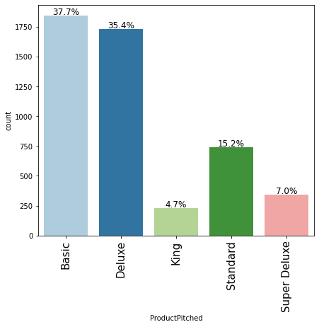

```python
labeled_barplot(df, "ProductPitched", perc=True)
```

##### Observation

- The most often pitched travel package was the Basic (38%) followed by the Deluxe (35%)
- Packages ordered as Basic, Standard, Deluxe, Super Deluxe, King

#### TypeofContact

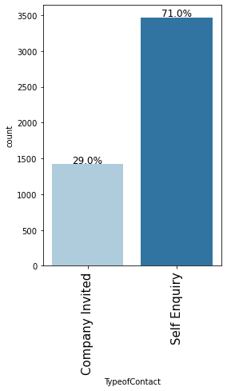

```python
labeled_barplot(df, "TypeofContact", perc=True)
```

##### Observation

- 71% of customers reported approaching Visit With Us with travel inquiries rather than being first contacted by company

#### ProdTaken (Target Variable)

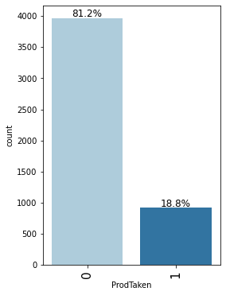

```python
labeled_barplot(df, "ProdTaken", perc=True)
```

##### Observation

- Close to 19% of customers bought a Visit With Us travel package

## Examining Relationships between Features and Target Variable (Bivariate Analysis)

##### Setting up functions for visualizations

```python
### function to plot distributions wrt target


def distribution_plot_wrt_target(data, predictor, target):

    fig, axs = plt.subplots(2, 2, figsize=(12, 10))

    target_uniq = data[target].unique()

    axs[0, 0].set_title("Distribution of target for target=" + str(target_uniq[0]))
    sns.histplot(
        data=data[data[target] == target_uniq[0]],
        x=predictor,
        kde=True,
        ax=axs[0, 0],
        color="teal",
        stat="density",
    )

    axs[0, 1].set_title("Distribution of target for target=" + str(target_uniq[1]))
    sns.histplot(
        data=data[data[target] == target_uniq[1]],
        x=predictor,
        kde=True,
        ax=axs[0, 1],
        color="orange",
        stat="density",
    )

    axs[1, 0].set_title("Boxplot w.r.t target")
    sns.boxplot(data=data, x=target, y=predictor, ax=axs[1, 0], palette="gist_rainbow")

    axs[1, 1].set_title("Boxplot (without outliers) w.r.t target")
    sns.boxplot(
        data=data,
        x=target,
        y=predictor,
        ax=axs[1, 1],
        showfliers=False,
        palette="gist_rainbow",
    )

    plt.tight_layout()
    plt.show()
```

```python
# function to plot stacked bar chart

def stacked_barplot(data, predictor, target):
    """
    Print the category counts and plot a stacked bar chart

    data: dataframe
    predictor: independent variable
    target: target variable
    """
    count = data[predictor].nunique()
    sorter = data[target].value_counts().index[-1]
    tab1 = pd.crosstab(data[predictor], data[target], margins=True).sort_values(
        by=sorter, ascending=False
    )
    print(tab1)
    print("-" * 120)
    tab = pd.crosstab(data[predictor], data[target], normalize="index").sort_values(
        by=sorter, ascending=False
    )
    tab.plot(kind="bar", stacked=True, figsize=(count + 5, 6))
    plt.legend(
        loc="lower left", frameon=False,
    )
    plt.legend(loc="upper left", bbox_to_anchor=(1, 1))
    plt.show()
```

#### Examining Target Variable Relationships with Numeric Features

```python
cont_var = df[['MonthlyIncome', 'Age', 'DurationOfPitch','ProdTaken']]
```

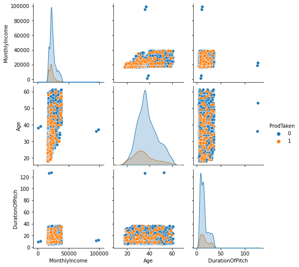

```python
sns.pairplot(cont_var, hue='ProdTaken')
plt.show()
```

##### Observation

- From the distributions above, it appears that in terms of age, monthly income, and duration of pitch, customers who purchased travel package do not differ strikingly from those who did not

```python
num_var = df[['ProdTaken', 'MonthlyIncome', 'Age','DurationOfPitch','NumberOfPersonVisiting', 'NumberOfFollowups', 'NumberOfTrips', 'NumberOfChildrenVisiting','PitchSatisfactionScore']]
```

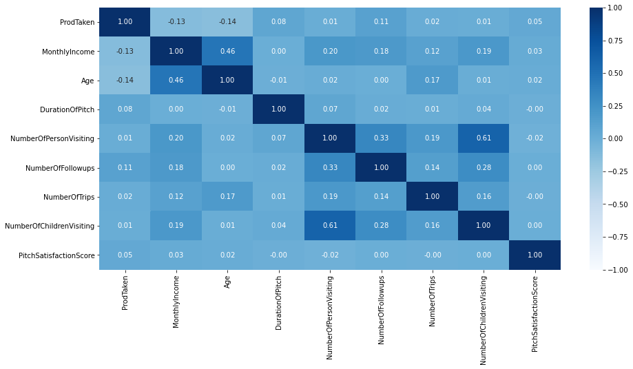

```python
plt.figure(figsize=(15, 7))
sns.heatmap(num_var.corr(), annot=True, vmin=-1, vmax=1, fmt=".2f", cmap="Blues")
plt.show()
```

##### Observation

- We do not observe correlations between the features 'MonthlyIncome', 'Age','DurationOfPitch','NumberOfPersonVisiting', 'NumberOfFollowups', 'NumberOfTrips', 'NumberOfChildrenVisiting','PitchSatisfactionScore' and the target variable, 'ProdTaken'
- The highest ProdTaken correlation values being very mild negative correlations, -0.13 and -0.14 with Monthly Income and Age, respectively
- We observe a positive correlation, 0.46, between Age and Monthly Income

#### Age

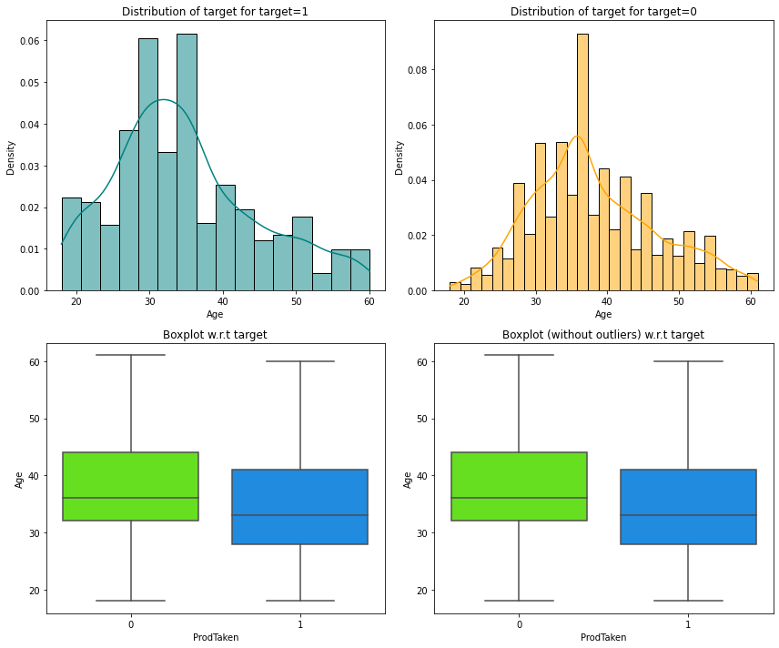

```python
distribution_plot_wrt_target(df, 'Age', 'ProdTaken')
```

#### Observation

- The graphs above give us an idea of the distributions separated between customers who purchased a travel package vs did not and accounting for the presence of outliers
- We can see that because the distribution of Age values did not have outliers, that the boxplots give us the same results, showing that the age distribution for those who bought a travel package is slightly lower/younger than for those who did not buy

#### DurationOfPitch

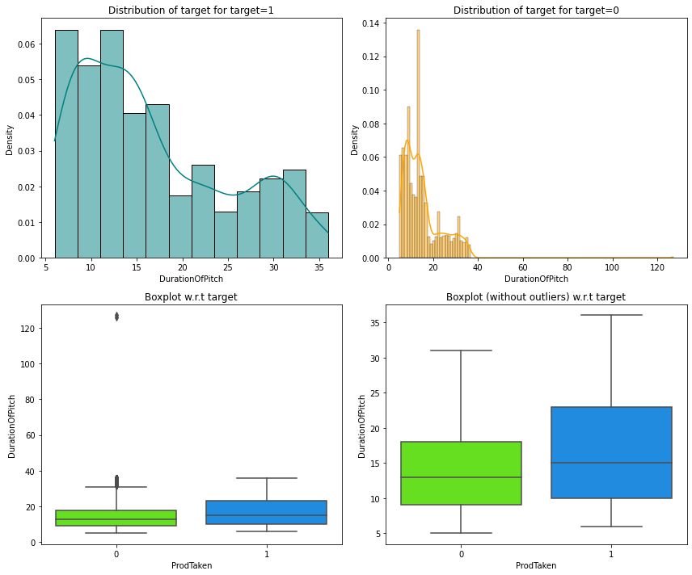

```python
distribution_plot_wrt_target(df, 'DurationOfPitch', 'ProdTaken')
```

##### Observation

- Without outliers, we see that duration of pitch was on average longer for customers who purchased a travel package

#### MonthlyIncome

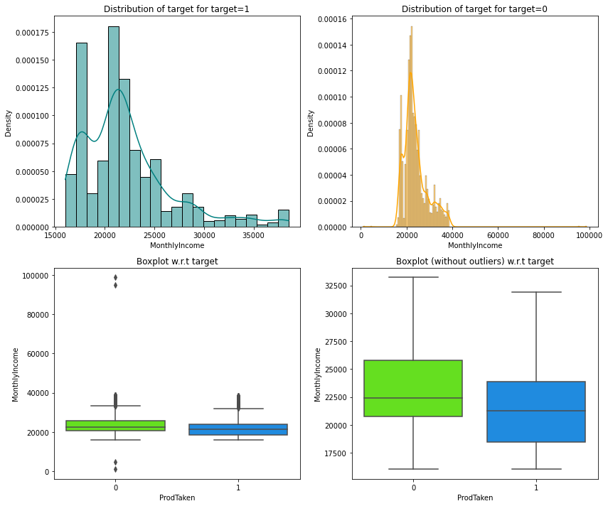

```python
distribution_plot_wrt_target(df, 'MonthlyIncome', 'ProdTaken')
```

##### Observation

- Looking at boxplots without the presence of outliers, we observe a monthly income distribution at lower income levels for customers who purchased a travel package